# HEART DISEASE DIAGNOSTIC ANALYSIS

The Goal of this project is to analyse the heart disease accurence,based on a combination of features that describe the heart disease.

I will use Python to perform all the data analysis and visualization. I start with importing the necessary modules for this project:Pandas,Numpy,Matplotlib.

Then the dataset is imported into the environment through the read.csv method.

```python
#Import Libraries
import pandas as pd
import numpy as np
import matplotlib.pyplot as plt
import seaborn as sns
import scipy.stats as stats
```

```python
#Extracting CSV Dataset From System
df=pd.read_csv("Heart Disease Data.csv")
```

```python
df
```

|  | age | sex | cp | trestbps | chol | fbs | restecg | thalach | exang | oldpeak | slope | ca | thal | target |
| --- | --- | --- | --- | --- | --- | --- | --- | --- | --- | --- | --- | --- | --- | --- |
| 0 | 52 | 1 | 0 | 125 | 212 | 0 | 1 | 168 | 0 | 1.0 | 2 | 2 | 3 | 0 |
| 1 | 53 | 1 | 0 | 140 | 203 | 1 | 0 | 155 | 1 | 3.1 | 0 | 0 | 3 | 0 |
| 2 | 70 | 1 | 0 | 145 | 174 | 0 | 1 | 125 | 1 | 2.6 | 0 | 0 | 3 | 0 |
| 3 | 61 | 1 | 0 | 148 | 203 | 0 | 1 | 161 | 0 | 0.0 | 2 | 1 | 3 | 0 |
| 4 | 62 | 0 | 0 | 138 | 294 | 1 | 1 | 106 | 0 | 1.9 | 1 | 3 | 2 | 0 |
| ... | ... | ... | ... | ... | ... | ... | ... | ... | ... | ... | ... | ... | ... | ... |
| 1020 | 59 | 1 | 1 | 140 | 221 | 0 | 1 | 164 | 1 | 0.0 | 2 | 0 | 2 | 1 |
| 1021 | 60 | 1 | 0 | 125 | 258 | 0 | 0 | 141 | 1 | 2.8 | 1 | 1 | 3 | 0 |
| 1022 | 47 | 1 | 0 | 110 | 275 | 0 | 0 | 118 | 1 | 1.0 | 1 | 1 | 2 | 0 |
| 1023 | 50 | 0 | 0 | 110 | 254 | 0 | 0 | 159 | 0 | 0.0 | 2 | 0 | 2 | 1 |
| 1024 | 54 | 1 | 0 | 120 | 188 | 0 | 1 | 113 | 0 | 1.4 | 1 | 1 | 3 | 0 |

1025 rows × 14 columns

```python
df.head()
```

|  | age | sex | cp | trestbps | chol | fbs | restecg | thalach | exang | oldpeak | slope | ca | thal | target |
| --- | --- | --- | --- | --- | --- | --- | --- | --- | --- | --- | --- | --- | --- | --- |
| 0 | 52 | 1 | 0 | 125 | 212 | 0 | 1 | 168 | 0 | 1.0 | 2 | 2 | 3 | 0 |
| 1 | 53 | 1 | 0 | 140 | 203 | 1 | 0 | 155 | 1 | 3.1 | 0 | 0 | 3 | 0 |
| 2 | 70 | 1 | 0 | 145 | 174 | 0 | 1 | 125 | 1 | 2.6 | 0 | 0 | 3 | 0 |
| 3 | 61 | 1 | 0 | 148 | 203 | 0 | 1 | 161 | 0 | 0.0 | 2 | 1 | 3 | 0 |
| 4 | 62 | 0 | 0 | 138 | 294 | 1 | 1 | 106 | 0 | 1.9 | 1 | 3 | 2 | 0 |

```python
df.tail()
```

|  | age | sex | cp | trestbps | chol | fbs | restecg | thalach | exang | oldpeak | slope | ca | thal | target |
| --- | --- | --- | --- | --- | --- | --- | --- | --- | --- | --- | --- | --- | --- | --- |
| 1020 | 59 | 1 | 1 | 140 | 221 | 0 | 1 | 164 | 1 | 0.0 | 2 | 0 | 2 | 1 |
| 1021 | 60 | 1 | 0 | 125 | 258 | 0 | 0 | 141 | 1 | 2.8 | 1 | 1 | 3 | 0 |
| 1022 | 47 | 1 | 0 | 110 | 275 | 0 | 0 | 118 | 1 | 1.0 | 1 | 1 | 2 | 0 |
| 1023 | 50 | 0 | 0 | 110 | 254 | 0 | 0 | 159 | 0 | 0.0 | 2 | 0 | 2 | 1 |
| 1024 | 54 | 1 | 0 | 120 | 188 | 0 | 1 | 113 | 0 | 1.4 | 1 | 1 | 3 | 0 |

```python
df.shape
```

```
(1025, 14)
```

```python
df.info()
```

```
<class 'pandas.core.frame.DataFrame'>
RangeIndex: 1025 entries, 0 to 1024
Data columns (total 14 columns):
 #   Column    Non-Null Count  Dtype
---  ------    --------------  -----
 0   age       1025 non-null   int64
 1   sex       1025 non-null   int64
 2   cp        1025 non-null   int64
 3   trestbps  1025 non-null   int64
 4   chol      1025 non-null   int64
 5   fbs       1025 non-null   int64
 6   restecg   1025 non-null   int64
 7   thalach   1025 non-null   int64
 8   exang     1025 non-null   int64
 9   oldpeak   1025 non-null   float64
 10  slope     1025 non-null   int64
 11  ca        1025 non-null   int64
 12  thal      1025 non-null   int64
 13  target    1025 non-null   int64
dtypes: float64(1), int64(13)
memory usage: 112.2 KB
```

```python
df.columns
```

```
Index(['age', 'sex', 'cp', 'trestbps', 'chol', 'fbs', 'restecg', 'thalach',
       'exang', 'oldpeak', 'slope', 'ca', 'thal', 'target'],
      dtype='object')
```

There are thirteen feature in Dataset  
age:The pearson's age in years  
sex:The Pearson's sex(1=Male,0=Female)  
cp:The chest pain experienced(Value 1:typical angina, Value2:atypical angina, Value 3:non-anginal pain,Value4:asympotomatic)  
trestbps:The person's resting blood pressure(mm Hg on admission to the hospital)  
chol:The person's cholestrol measurement in mg/dl  
fbs:The person's fasting blood sugar(>120 mg/dl,1=true;0=false)  
restecg:Resting electrocardiographic measurment (0=normal,1=havingST-T wave abnormality,2=showing proble or definite left ventricular  
thalach:The person's maximum heart rate achieved  
exang:Exercise induced angina(1=yes;0=no)  
oldpeak:ST depression induced by exercise relative to rest slope:The slope of the peak exercise ST segment (Value1:upsioping,Value2:flat,Value3:downsloping)  
ca:The number of major vessel(0-3)  
thal:A blood disorder called thalassemia(3=normal;6=fixed defect;7=reversable defect)  
num:Heart disease(0=no,1=yes)

```python
df.describe()
```

|  | age | sex | cp | trestbps | chol | fbs | restecg | thalach | exang | oldpeak | slope | ca | thal | target |
| --- | --- | --- | --- | --- | --- | --- | --- | --- | --- | --- | --- | --- | --- | --- |
| count | 1025.000000 | 1025.000000 | 1025.000000 | 1025.000000 | 1025.00000 | 1025.000000 | 1025.000000 | 1025.000000 | 1025.000000 | 1025.000000 | 1025.000000 | 1025.000000 | 1025.000000 | 1025.000000 |
| mean | 54.434146 | 0.695610 | 0.942439 | 131.611707 | 246.00000 | 0.149268 | 0.529756 | 149.114146 | 0.336585 | 1.071512 | 1.385366 | 0.754146 | 2.323902 | 0.513171 |
| std | 9.072290 | 0.460373 | 1.029641 | 17.516718 | 51.59251 | 0.356527 | 0.527878 | 23.005724 | 0.472772 | 1.175053 | 0.617755 | 1.030798 | 0.620660 | 0.500070 |
| min | 29.000000 | 0.000000 | 0.000000 | 94.000000 | 126.00000 | 0.000000 | 0.000000 | 71.000000 | 0.000000 | 0.000000 | 0.000000 | 0.000000 | 0.000000 | 0.000000 |
| 25% | 48.000000 | 0.000000 | 0.000000 | 120.000000 | 211.00000 | 0.000000 | 0.000000 | 132.000000 | 0.000000 | 0.000000 | 1.000000 | 0.000000 | 2.000000 | 0.000000 |
| 50% | 56.000000 | 1.000000 | 1.000000 | 130.000000 | 240.00000 | 0.000000 | 1.000000 | 152.000000 | 0.000000 | 0.800000 | 1.000000 | 0.000000 | 2.000000 | 1.000000 |
| 75% | 61.000000 | 1.000000 | 2.000000 | 140.000000 | 275.00000 | 0.000000 | 1.000000 | 166.000000 | 1.000000 | 1.800000 | 2.000000 | 1.000000 | 3.000000 | 1.000000 |
| max | 77.000000 | 1.000000 | 3.000000 | 200.000000 | 564.00000 | 1.000000 | 2.000000 | 202.000000 | 1.000000 | 6.200000 | 2.000000 | 4.000000 | 3.000000 | 1.000000 |

```python
target=df.groupby('target').size()
target
```

```
target
0    499
1    526
dtype: int64
```

```python
def heart_d(r):
    if r==0:
        return 'Absence'
    elif r==1:
        return 'Presence'
```

```python
df['Heart_Disease']=df['target'].apply(heart_d)
df.head()
```

|  | age | sex | cp | trestbps | chol | fbs | restecg | thalach | exang | oldpeak | slope | ca | thal | target | Heart_Disease |
| --- | --- | --- | --- | --- | --- | --- | --- | --- | --- | --- | --- | --- | --- | --- | --- |
| 0 | 52 | 1 | 0 | 125 | 212 | 0 | 1 | 168 | 0 | 1.0 | 2 | 2 | 3 | 0 | Absence |
| 1 | 53 | 1 | 0 | 140 | 203 | 1 | 0 | 155 | 1 | 3.1 | 0 | 0 | 3 | 0 | Absence |
| 2 | 70 | 1 | 0 | 145 | 174 | 0 | 1 | 125 | 1 | 2.6 | 0 | 0 | 3 | 0 | Absence |
| 3 | 61 | 1 | 0 | 148 | 203 | 0 | 1 | 161 | 0 | 0.0 | 2 | 1 | 3 | 0 | Absence |
| 4 | 62 | 0 | 0 | 138 | 294 | 1 | 1 | 106 | 0 | 1.9 | 1 | 3 | 2 | 0 | Absence |

```python
hd=df.groupby('Heart_Disease')['target'].count()
hd
```

```
Heart_Disease
Absence     499
Presence    526
Name: target, dtype: int64
```

```python
def gen(r):
    if r==1:
        return 'Male'
    elif r==0:
        return "Female"
```

```python
df["sex1"]=df['sex'].apply(gen)
df.head()
```

|  | age | sex | cp | trestbps | chol | fbs | restecg | thalach | exang | oldpeak | slope | ca | thal | target | Heart_Disease | sex1 |
| --- | --- | --- | --- | --- | --- | --- | --- | --- | --- | --- | --- | --- | --- | --- | --- | --- |
| 0 | 52 | 1 | 0 | 125 | 212 | 0 | 1 | 168 | 0 | 1.0 | 2 | 2 | 3 | 0 | Absence | Male |
| 1 | 53 | 1 | 0 | 140 | 203 | 1 | 0 | 155 | 1 | 3.1 | 0 | 0 | 3 | 0 | Absence | Male |
| 2 | 70 | 1 | 0 | 145 | 174 | 0 | 1 | 125 | 1 | 2.6 | 0 | 0 | 3 | 0 | Absence | Male |
| 3 | 61 | 1 | 0 | 148 | 203 | 0 | 1 | 161 | 0 | 0.0 | 2 | 1 | 3 | 0 | Absence | Male |
| 4 | 62 | 0 | 0 | 138 | 294 | 1 | 1 | 106 | 0 | 1.9 | 1 | 3 | 2 | 0 | Absence | Female |

```python
def age_rng(r):
    if r>=29 and r<40:
        return 'young Age'
    elif r>=40 and r<55:
        return 'Middle Age'
    elif r>55:
        return 'Elder Age'
```

```python
df['Age_Range']=df['age'].apply(age_rng)
df.head()
```

|  | age | sex | cp | trestbps | chol | fbs | restecg | thalach | exang | oldpeak | slope | ca | thal | target | Heart_Disease | sex1 | Age_Range |
| --- | --- | --- | --- | --- | --- | --- | --- | --- | --- | --- | --- | --- | --- | --- | --- | --- | --- |
| 0 | 52 | 1 | 0 | 125 | 212 | 0 | 1 | 168 | 0 | 1.0 | 2 | 2 | 3 | 0 | Absence | Male | Middle Age |
| 1 | 53 | 1 | 0 | 140 | 203 | 1 | 0 | 155 | 1 | 3.1 | 0 | 0 | 3 | 0 | Absence | Male | Middle Age |
| 2 | 70 | 1 | 0 | 145 | 174 | 0 | 1 | 125 | 1 | 2.6 | 0 | 0 | 3 | 0 | Absence | Male | Elder Age |
| 3 | 61 | 1 | 0 | 148 | 203 | 0 | 1 | 161 | 0 | 0.0 | 2 | 1 | 3 | 0 | Absence | Male | Elder Age |
| 4 | 62 | 0 | 0 | 138 | 294 | 1 | 1 | 106 | 0 | 1.9 | 1 | 3 | 2 | 0 | Absence | Female | Elder Age |

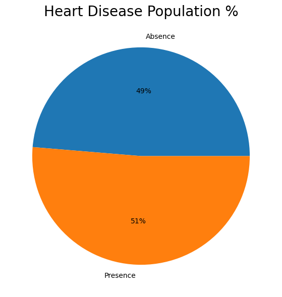

```python
#Pie  chart creation of heart disease population
plt.figure(figsize=(10,7))
plt.pie(hd,labels=['Absence','Presence'],autopct='%0.0f%%')
plt.title('Heart Disease Population %',fontsize=20 )
plt.show()
```

From the overall population, pepole having heart disease(51%) are grater than those who have heart disease(49%)

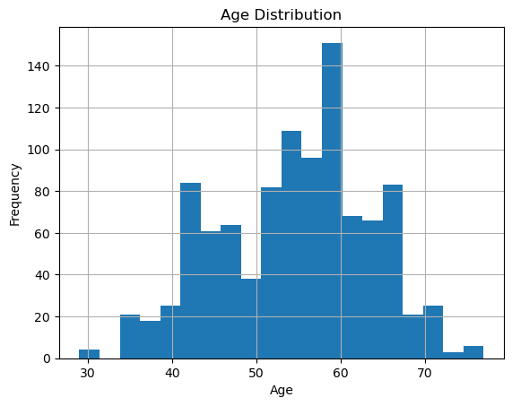

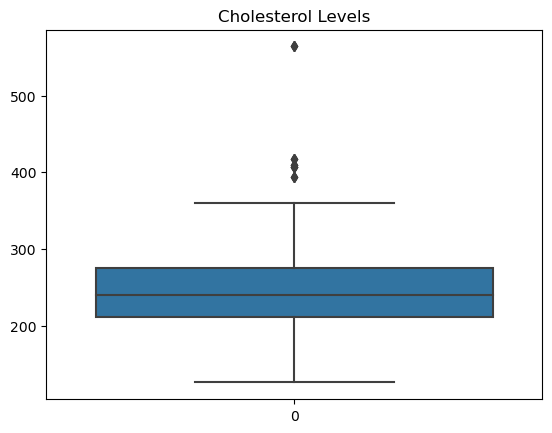

```python
#univeriate analysis
#numerical veriable
df['age'].hist(bins=20)
plt.title('Age Distribution')
plt.xlabel('Age')
plt.ylabel('Frequency')
plt.show()
sns.boxplot(df['chol'])
plt.title('Cholesterol Levels')
plt.show()
```

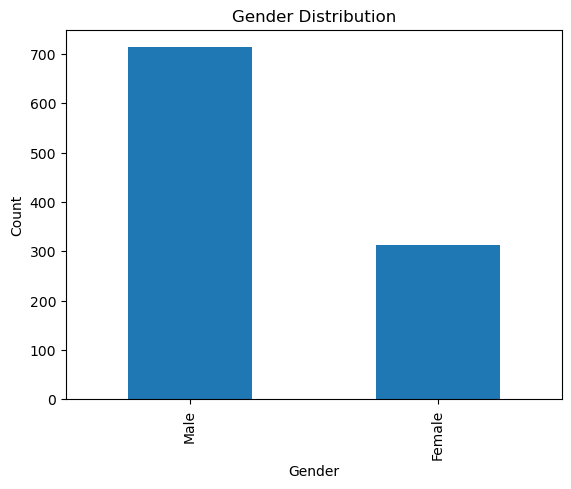

```python
#categorical veriabel
df['sex1'].value_counts().plot(kind='bar')
plt.title('Gender Distribution')
plt.xlabel('Gender')
plt.ylabel('Count')
plt.show()
```

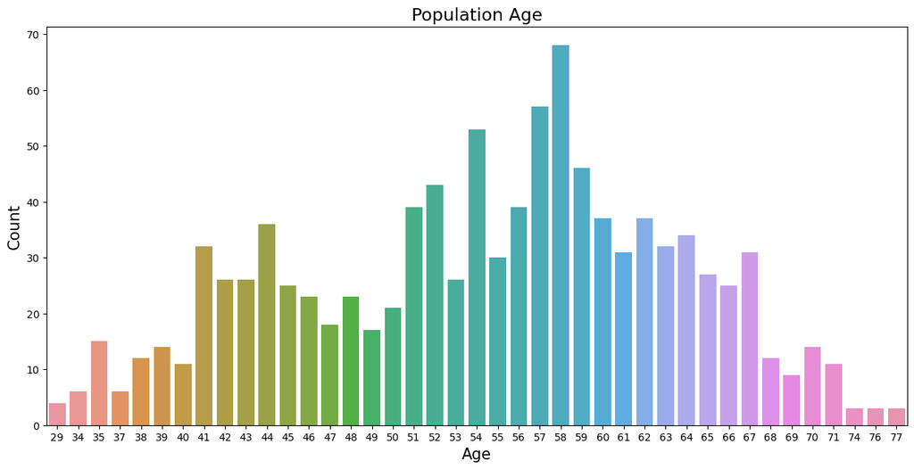

```python
#count plot cration of population
plt.figure(figsize=(15,7))
sns.countplot(x ='age',data=df)
plt.title('Population Age',fontsize=17)
plt.xlabel('Age',fontsize=15)
plt.ylabel('Count',fontsize=15)
plt.show()
```

In this section, the best analysis can be divided into the elderly,middle-aged, young people by looking at the age ranges

```python
#statistical analysis
Min_Age=df['age'].min()
Max_Age=df['age'].max()
Mean_Age=df['age'].mean()
print("Minimum Age=",Min_Age)
print("Maximum Age=",Max_Age)
print("Mean Age=",Mean_Age)
```

```
Minimum Age= 29
Maximum Age= 77
Mean Age= 54.43414634146342
```

```python
#catogorical analysis
Young_Age=df[(df['age']>=29)&(df['age']<40)]
Middle_Age=df[(df['age']>=40)&(df['age']<55)]
Elder_Age=df[(df['age']>55)]
print('Young Age =',len(Young_Age))
print('Middle Age =',len(Middle_Age))
print('Elder Age =',len(Elder_Age))
```

```
Young Age = 57
Middle Age = 419
Elder Age = 519
```

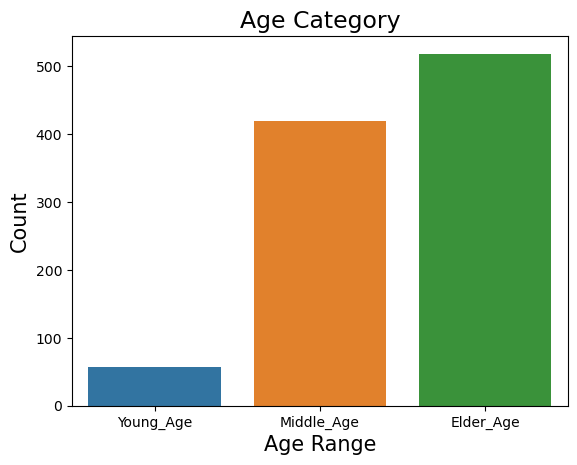

```python
#Bar plot creation of age category using matplotlib and seaborn
sns.barplot(x=['Young_Age','Middle_Age','Elder_Age'],y=[len(Young_Age),len(Middle_Age),len(Elder_Age)])
plt.title('Age Category',fontsize=17)
plt.xlabel('Age Range',fontsize=15)
plt.ylabel('Count',fontsize=15)
plt.show()
```

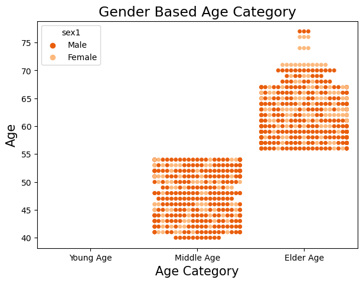

```python
#swarm plot creation of gender based age category using matplotlib and seaborn
plt.figure(figsize=(7,5))
sns.swarmplot(x='Age_Range',y='age',hue='sex1',data=df,order=['Young Age','Middle Age','Elder Age'],palette='Oranges_r')
plt.title('Gender Based Age Category',fontsize=17)
plt.xlabel('Age Category',fontsize=15)
plt.ylabel('Age',fontsize=15)
plt.show()
```

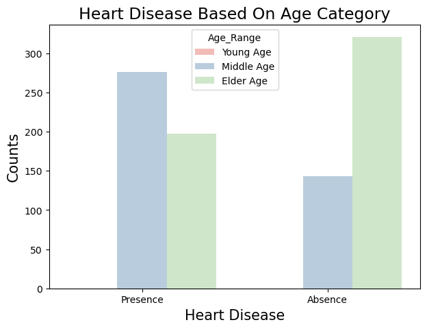

```python
#Count plot cration of Heart disease based On Age Category
plt.figure(figsize=(7,5))
hue_order=['Young Age','Middle Age','Elder Age']
sns.countplot(x='Heart_Disease',hue='Age_Range',data=df,order=['Presence','Absence'],hue_order=hue_order,palette='Pastel1')
plt.title('Heart Disease Based On Age Category',fontsize=17)
plt.xlabel('Heart Disease',fontsize=15)
plt.ylabel('Counts',fontsize=15)
plt.show()
```

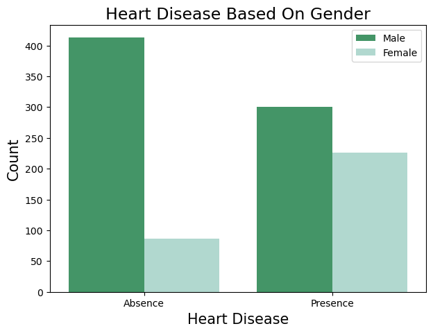

```python
#count  plot creation of heart disease based on gender using matplotlib and seaborn
plt.figure(figsize=(7,5))
sns.countplot(x=df['Heart_Disease'],hue='sex1', data=df,palette='BuGn_r')
plt.xlabel('Heart Disease',fontsize=15)
plt.ylabel('Count',fontsize=15)
plt.legend(labels=['Male','Female'])
plt.title('Heart Disease Based On Gender',fontsize=17)
plt.show()
```

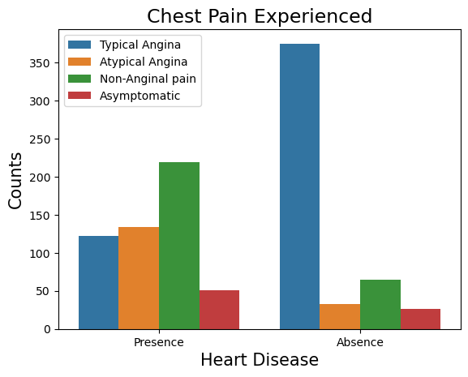

```python
#count plot creation of chest pain experienced using matplotlib and seaborn
sns.countplot(x=df['Heart_Disease'],hue='cp', data=df,order=['Presence','Absence'])
plt.title('Chest Pain Experienced',fontsize=17)
plt.xlabel('Heart Disease',fontsize=15)
plt.ylabel('Counts',fontsize=15)
plt.legend(labels=['Typical Angina','Atypical Angina','Non-Anginal pain','Asymptomatic'])
plt.show()
```

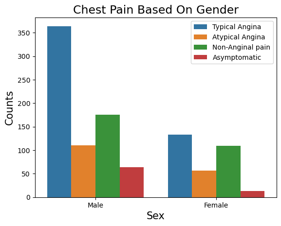

```python
#count plot cration of chest pain based on gender using matplotlib and seaborn
sns.countplot(x=df['sex1'],hue='cp',data=df)
plt.title('Chest Pain Based On Gender',fontsize=17)
plt.xlabel('Sex',fontsize=15)
plt.ylabel('Counts',fontsize=15)
plt.legend(labels=['Typical Angina','Atypical Angina','Non-Anginal pain','Asymptomatic'])
plt.show()
```

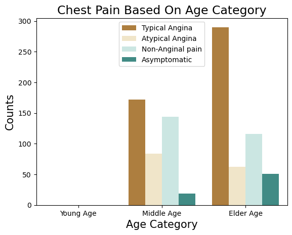

```python
#count plot cration of Chest Pain On Age Category
sns.countplot(x=df['Age_Range'],hue='cp',data=df,order=['Young Age','Middle Age','Elder Age'],palette='BrBG')
plt.title('Chest Pain Based On Age Category', fontsize=17)
plt.xlabel('Age Category',fontsize=15)
plt.ylabel('Counts',fontsize=15)
plt.legend(labels=['Typical Angina','Atypical Angina','Non-Anginal pain','Asymptomatic'])
plt.show()
```

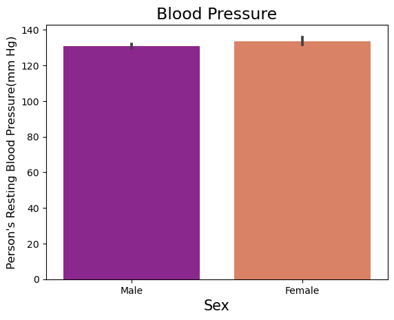

```python
#bar plot creation of persons resting blood pressure(mm hg) using matplotlib and seaborn
sns.barplot(x='sex1',y='trestbps',data=df,palette='plasma')
plt.title('Blood Pressure',fontsize=17)
plt.xlabel('Sex',fontsize=15)
plt.ylabel("Person's Resting Blood Pressure(mm Hg)",fontsize=12)
plt.show()
```

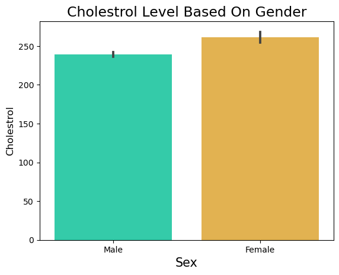

```python
#barplot creation of cholestrol level based on gender using matplotlib and seaborn
sns.barplot(x='sex1',y='chol',data=df,palette='turbo')
plt.title('Cholestrol Level Based On Gender',fontsize=17)
plt.xlabel('Sex',fontsize=15)
plt.ylabel("Cholestrol",fontsize=12)
plt.show()
```

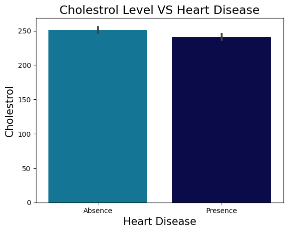

```python
#bar plot creation of cholestrol vs heart disease using matplotlib and seaborn
sns.barplot(x='Heart_Disease',y='chol',data=df,palette='ocean_r')
plt.title('Cholestrol Level VS Heart Disease',fontsize=17)
plt.xlabel('Heart Disease',fontsize=15)
plt.ylabel("Cholestrol",fontsize=15)
plt.show()
```

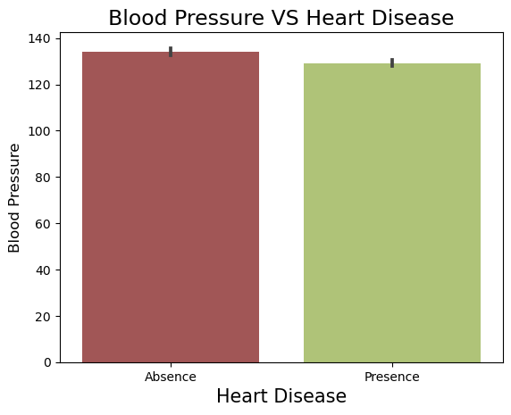

```python
#bar plot cration of blood pressure VS heart disease using matplotlib and seaborn
sns.barplot(x='Heart_Disease',y='trestbps',data=df,palette='tab20b_r')
plt.title('Blood Pressure VS Heart Disease',fontsize=17)
plt.xlabel('Heart Disease',fontsize=15)
plt.ylabel("Blood Pressure",fontsize=12)
plt.show()
```

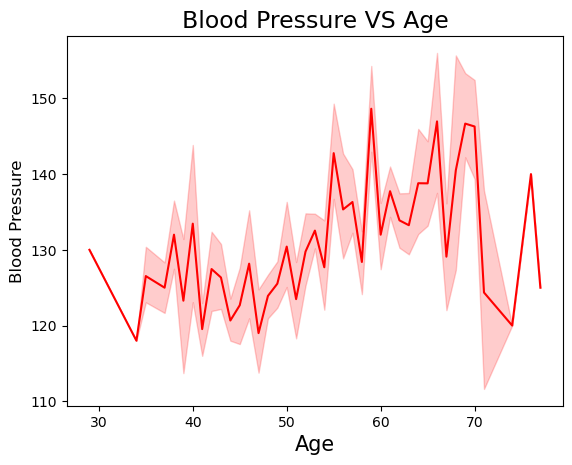

```python
#Line plot creation of blood pressure VS age using matplotlib and seaborn
sns.lineplot(x='age',y='trestbps',data=df,color='r')
plt.title('Blood Pressure VS Age',fontsize=17)
plt.xlabel('Age',fontsize=15)
plt.ylabel("Blood Pressure",fontsize=12)
plt.show()
```

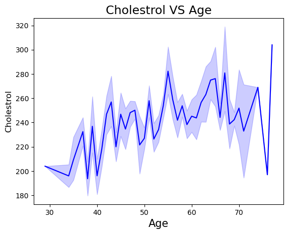

```python
#line p,ot cration of cholestrol VS age using matplotlib and seaborn
sns.lineplot(x='age',y='chol',data=df,color='b')
plt.title('Cholestrol VS Age',fontsize=17)
plt.xlabel('Age',fontsize=15)
plt.ylabel("Cholestrol",fontsize=12)
plt.show()
```

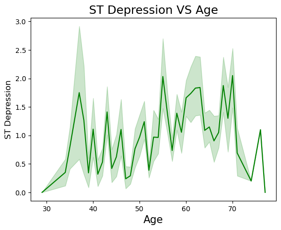

```python
#line plot creation of ST depression VS age using matplotlib and seaborn
sns.lineplot(x='age',y='oldpeak',data=df,color='g')
plt.title('ST Depression VS Age',fontsize=17)
plt.xlabel('Age',fontsize=15)
plt.ylabel("ST Depression",fontsize=12)
plt.show()
```

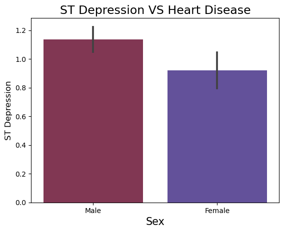

```python
#bar plot cration of ST depression VS heart disease using matplotlib and seaborn
sns.barplot(x='sex1',y='oldpeak',data=df,palette='twilight_r')
plt.title('ST Depression VS Heart Disease',fontsize=17)
plt.xlabel('Sex',fontsize=15)
plt.ylabel("ST Depression",fontsize=12)
plt.show()
```

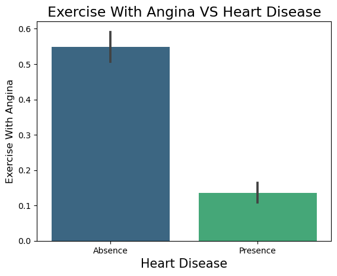

```python
#bar plot creation of exercise with angina VS heart disease using matplotlib and seaborn
sns.barplot(x='Heart_Disease',y='exang',data=df,palette='viridis')
plt.title('Exercise With Angina VS Heart Disease',fontsize=17)
plt.xlabel('Heart Disease',fontsize=15)
plt.ylabel("Exercise With Angina",fontsize=12)
plt.show()
```

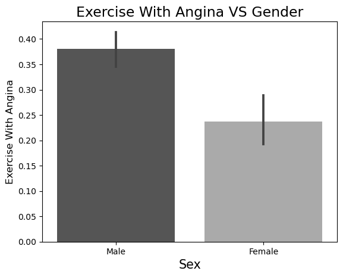

```python
#bar plot creation of excercise with angina VS gender using matplotlib and seaborn
sns.barplot(x='sex1',y='exang',data=df,palette='binary_r')
plt.title('Exercise With Angina VS Gender',fontsize=17)
plt.xlabel('Sex',fontsize=15)
plt.ylabel("Exercise With Angina",fontsize=12)
plt.show()
```

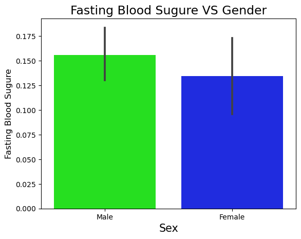

```python
#bar plot creation fasting blood sugure VS gender using matplotlib and seaborn
sns.barplot(x='sex1',y='fbs',data=df,palette='hsv')
plt.title('Fasting Blood Sugure VS Gender',fontsize=17)
plt.xlabel('Sex',fontsize=15)
plt.ylabel("Fasting Blood Sugure",fontsize=12)
plt.show()
```

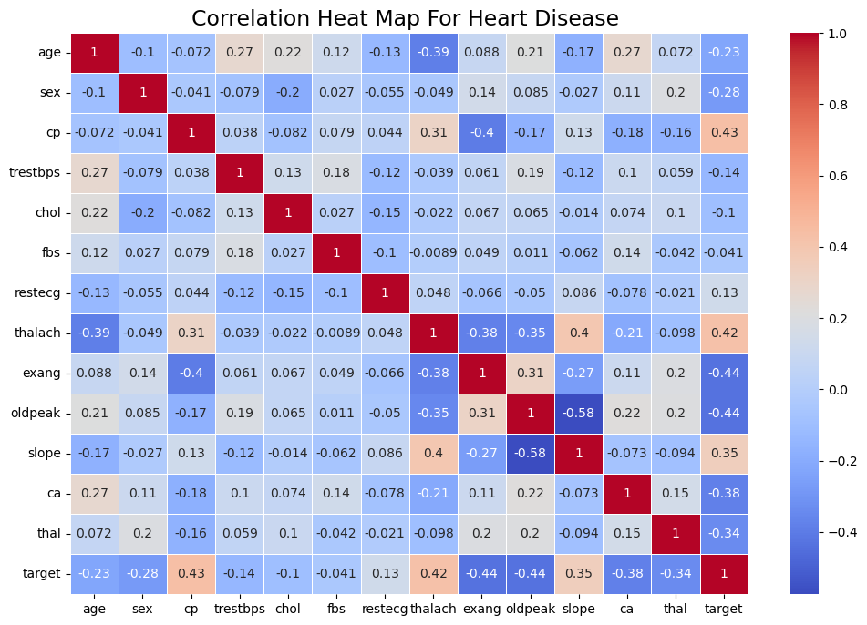

```python
#heatmap cration using seaborn
df.dtypes
numeric_data=df.select_dtypes(include=['float64','int64'])
numeric_data=numeric_data.fillna(numeric_data.median())
correlation_matrix=numeric_data.corr()
plt.figure(figsize=(12,8))
sns.heatmap(correlation_matrix,annot=True,cmap='coolwarm',linewidths=0.5)
plt.title('Correlation Heat Map For Heart Disease ',fontsize=17)
plt.show()
```